# Practicum 1 / Design & Implement a Relational Database

Jai Iyyappa Vignesh Manivannan

####Implementing my ER diagram into relational table using MySQL.

### Name: Jai Iyyappa Vignesh Manivannan

### Email: manivannan.j@northeastern.edu

## Question 1 - ER Diagram

[video not shown]

##### Embed Link : https://lucid.app/documents/embeddedchart/c98f4ea6-b6ca-4943-b32a-51e96e58fcf4

##### PDF Link : https://lucid.app/publicSegments/view/99651166-e249-440a-b196-5d4a69c9fb02/image.pdf

## Question 2 , 3 - DDL Commands & excel read

```r
# Installing the RMySQL Library
library(RMySQL)
#  MySQL Settings
db_user <- 'admin'
db_password <- 'Vermithor23!!'
db_name <- 'Practicum1DB'
db_host <- 'manivannancs5200su21.cnoba73kt4gp.us-east-1.rds.amazonaws.com'
db_port <- 3306

# Establishing a connection to MySQL
mydb <-  dbConnect(MySQL(), user = db_user, password = db_password,
                  dbname = db_name, host = db_host, port = db_port)
```

### Load CSV Data

```r
fn <- "BirdStrikesData.csv"

df.raw <- read.csv(file = fn,
                   header = T,
                   stringsAsFactors = F)
```

```r
head(df.raw, 3)
```

|  | ï..Record.ID | Aircraft..Type | Airport..Name | Altitude.bin | Aircraft..Make.Model | Wildlife..Number.struck | Wildlife..Number.Struck.Actual | Effect..Impact.to.flight | FlightDate | Effect..Indicated.Damage | Aircraft..Number.of.engines. | Aircraft..Airline.Operator | Origin.State | When..Phase.of.flight | Conditions..Precipitation | Remains.of.wildlife.collected. | Remains.of.wildlife.sent.to.Smithsonian | Remarks | Wildlife..Size | Conditions..Sky | Wildlife..Species | Pilot.warned.of.birds.or.wildlife. | Cost..Total.. | Feet.above.ground | Number.of.people.injured | Is.Aircraft.Large. |
| --- | --- | --- | --- | --- | --- | --- | --- | --- | --- | --- | --- | --- | --- | --- | --- | --- | --- | --- | --- | --- | --- | --- | --- | --- | --- | --- |
| 1 | 202152 | Airplane | LAGUARDIA NY | > 1000 ft | B-737-400 | Over 100 | 859 | Engine Shut Down | 11/23/2000 0:00 | Caused damage | 2 | US AIRWAYS* | New York | Climb | None | FALSE | FALSE | FLT 753. PILOT REPTD A HUNDRED BIRDS ON UNKN TYPE. #1 ENG WAS SHUT DOWN AND DIVERTED TO EWR. SLIGHT VIBRATION. A/C WAS OUT OF SVC FOR REPAIRS TO COWLING, FAN DUCT ACCOUSTIC PANEL. INGESTION. DENTED FA… | Medium | No Cloud | Unknown bird - medium | N | 30,736 | 1,500 | 0 | Yes |
| 2 | 208159 | Airplane | DALLAS/FORT WORTH INTL ARPT | < 1000 ft | MD-80 | Over 100 | 424 | None | 7/25/2001 0:00 | Caused damage | 2 | AMERICAN AIRLINES | Texas | Landing Roll | None | FALSE | FALSE | 102 CARCASSES FOUND. 1 LDG LIGHT ON NOSE GEAR WAS DAMAGED AND REPLACED. | Small | Some Cloud | Rock pigeon | Y | 0 | 0 | 0 | No |
| 3 | 207601 | Airplane | LAKEFRONT AIRPORT | < 1000 ft | C-500 | Over 100 | 261 | None | 9/14/2001 0:00 | No damage | 2 | BUSINESS | Louisiana | Approach | None | FALSE | FALSE | FLEW UNDER A VERY LARGE FLOCK OF BIRDS OVER APCH END OF RWY. NO DMG. JUST A LOT OF BIRD DROPPINGS ON WINDSCREEN. | Small | No Cloud | European starling | N | 0 | 50 | 0 | No |

### Omitting empty aircraft data

#### All entries which didn’t have aircraft info didn’t have the airport information, so omitting it.

```r
totalRowBeforeOmit <- nrow(df.raw)

df.newRaw <- df.raw

if(any(df.raw$ Airport..Name == "")) {
  rs = which(df.raw$ Airport..Name == "")

  df.newRaw <- df.raw[-rs,]
}

totalNewRowAfterOmit <- nrow(df.newRaw)
```

```r
detach("package:RMySQL")

library(sqldf)
```

### Dropping reference table Accidents

```sql
DROP TABLE IF EXISTS Accidents
```

### Creation of table Airport

- airportId is the PRIMARY KEY

```sql
DROP TABLE IF EXISTS Airport
```

```sql
CREATE TABLE Airport(
airportId INT NOT NULL,
airportName VARCHAR(255) NOT NULL,
PRIMARY KEY (airportId)
)
```

### Extract the Airport Data from excel

```r
# Extracting the airport data from excel into a dataframe df.Airport.
df.Airport <- sqldf::sqldf("select 1 as airportId, `Airport..Name` as airportName from `df.newRaw` group by airportName")

# Calculating the total number of rows in df.Airport created.

n.Airport <- nrow(df.Airport)

# Changing the sequence number of hard-coded airportId value for PK.
df.Airport[,1] <- seq(1, n.Airport)
```

### Inserting the airport data into table

```r
# dbWriteTable is used with append to insert the data from dataframe into table.
dbWriteTable(mydb, 'Airport', df.Airport, row.names=F,append=T, overwrite=F)
```

```
## [1] TRUE
```

### Display Airport table

```sql
SELECT * FROM Airport
       LIMIT 5;
```

5 records

| airportId | airportName |
| --- | --- |
| 1 | ABERDEEN REGIONAL AR |
| 2 | ABILENE REGIONAL ARPT |
| 3 | ABRAHAM LINCOLN CAPITAL ARPT |
| 4 | ADAMS COUNTY- LEGION FIELD |
| 5 | ADAMS FIELD ARPT |

### Creation of table Airline

- airlineId is the PRIMARY KEY

```sql
DROP TABLE IF EXISTS Airline
```

```sql
CREATE TABLE Airline(
airlineId INT NOT NULL,
airlineOperator VARCHAR(255) NOT NULL,
PRIMARY KEY (airlineId)
)
```

### Extract the Airline Data from excel

```r
# Extracting the Airline data from excel into a dataframe df.Airline
df.Airline <- data.frame(
                         airlineId = 1,
                         airlineOperator = unique(df.newRaw$Aircraft..Airline.Operator)
                         )

# Calculating the total number of rows in df.Airline created.
n.Airline <- nrow(df.Airline)

# Changing the sequence number of hard-coded airlineId value for PK.
df.Airline[,1] <- seq(1, n.Airline)
```

### Inserting the Airline data into table

```r
# dbWriteTable is used with append to insert the data from dataframe into table.
dbWriteTable(mydb, 'Airline', df.Airline, row.names=F, append=T, overwrite=F)
```

```
## [1] TRUE
```

### Display Airline table

```sql
SELECT * FROM Airline
       LIMIT 5;
```

5 records

| airlineId | airlineOperator |
| --- | --- |
| 1 | US AIRWAYS* |
| 2 | AMERICAN AIRLINES |
| 3 | BUSINESS |
| 4 | ALASKA AIRLINES |
| 5 | COMAIR AIRLINES |

### Creation of table Aircraft

- aircraftId is the PRIMARY KEY

```sql
DROP TABLE IF EXISTS Aircraft
```

```sql
CREATE TABLE Aircraft(
aircraftId INT NOT NULL,
aircraftMake VARCHAR(100) NOT NULL,
PRIMARY KEY (aircraftId)
)
```

### Extract the Aircraft Data from excel

```r
# Extracting the Aircraft data from excel into a dataframe df.Aircraft
df.Aircraft <- data.frame(
                         aircraftId = 1,
                         aircraftMake = unique(df.newRaw$Aircraft..Make.Model)
                         )

# Calculating the total number of rows in df.Aircraft created.
n.Aircraft <- nrow(df.Aircraft)

# Changing the sequence number of hard-coded aircraftId value for PK.
df.Aircraft[,1] <- seq(1, n.Aircraft)
```

### Inserting the Aircraft data into table

```r
# dbWriteTable is used with append to insert the data from dataframe into table.
dbWriteTable(mydb, 'Aircraft', df.Aircraft, row.names=F, append=T, overwrite=F)
```

```
## [1] TRUE
```

### Display Aircraft table

```sql
SELECT * FROM Aircraft
       LIMIT 5;
```

5 records

| aircraftId | aircraftMake |
| --- | --- |
| 1 | B-737-400 |
| 2 | MD-80 |
| 3 | C-500 |
| 4 | CL-RJ100/200 |
| 5 | A-300 |

### Creation of table PhaseOfFlight

- phaseId is the PRIMARY KEY

```sql
DROP TABLE IF EXISTS PhaseOfFlight
```

```sql
CREATE TABLE PhaseOfFlight(
phaseId INT NOT NULL,
phaseName VARCHAR(100) NOT NULL,
PRIMARY KEY (phaseId)
)
```

### Extract the PhaseOfFlight Data from excel

```r
# Extracting the PhaseOfFlight data from excel into a dataframe df.PhaseOfFlight with hardcoded phaseId
df.PhaseOfFlight <- data.frame(
                         phaseId = 1,
                         phaseName = unique(df.newRaw$When..Phase.of.flight)
                         )

# Calculating the total number of rows in df.PhaseOfFlight created.
n.PhaseOfFlight <- nrow(df.PhaseOfFlight)

# Changing the sequence number of hard-coded phaseId value for PK.
df.PhaseOfFlight[,1] <- seq(1, n.PhaseOfFlight)
```

### Inserting the PhaseOfFlight data into table

```r
# dbWriteTable is used with append to insert the data from dataframe into table.
dbWriteTable(mydb, 'PhaseOfFlight', df.PhaseOfFlight, row.names=F, append=T, overwrite=F)
```

```
## [1] TRUE
```

#### Display PhaseOfFlight table

```sql
SELECT * FROM PhaseOfFlight
       LIMIT 5;
```

5 records

| phaseId | phaseName |
| --- | --- |
| 1 | Climb |
| 2 | Landing Roll |
| 3 | Approach |
| 4 | Take-off run |
| 5 | Descent |

### Creation of table Wildlife

- wildlifeId is the PRIMARY KEY

```sql
DROP TABLE IF EXISTS Wildlife
```

```sql
CREATE TABLE Wildlife(
wildlifeId INT NOT NULL,
wildlifeName VARCHAR(100) NOT NULL,
PRIMARY KEY (wildlifeId)
)
```

### Extract the Wildlife Data from excel

```r
# Extracting the Wildlife data from excel into a dataframe df.Wildlife with hardcoded wildlifeId
df.Wildlife <- data.frame(
                         wildlifeId = 1,
                         wildlifeName = unique(df.newRaw$Wildlife..Species)
                         )





# Calculating the total number of rows in df.Wildlife created.
n.Wildlife <- nrow(df.Wildlife)

# Changing the sequence number of hard-coded wildlifeId value for PK.
df.Wildlife[,1] <- seq(1, n.Wildlife)
```

### Inserting the Wildlife data into table

```r
# dbWriteTable is used with append to insert the data from dataframe into table.
dbWriteTable(mydb, 'Wildlife', df.Wildlife, row.names=F, append=T, overwrite=F)
```

```
## [1] TRUE
```

### Display Wildlife table

```sql
SELECT * FROM Wildlife
       LIMIT 5;
```

5 records

| wildlifeId | wildlifeName |
| --- | --- |
| 1 | Unknown bird - medium |
| 2 | Rock pigeon |
| 3 | European starling |
| 4 | Unknown bird - small |
| 5 | Canada goose |

### Creation of table precipitateCondition

- pConditionId is the PRIMARY KEY

```sql
DROP TABLE IF EXISTS accidentPrecipitateMap
```

```sql
DROP TABLE IF EXISTS precipitateCondition
```

```sql
CREATE TABLE precipitateCondition(
pConditionId INT NOT NULL,
pConditionName VARCHAR(100) NOT NULL,
PRIMARY KEY (pConditionId)
)
```

### Extract the precipitateCondition Data from excel

```r
s <- strsplit(unique(df.newRaw$Conditions..Precipitation) , ",")

s <- unlist(s)

s <- gsub( " ", "", s)

# Extracting the precipitateCondition data from excel into a dataframe df.precipitateCondition with hardcoded pConditionId
df.precipitateCondition <- data.frame(
                         pConditionId = 1,
                         pConditionName = unique(s)
                         )

# Calculating the total number of rows in df.precipitateCondition created.
n.precipitateCondition <- nrow(df.precipitateCondition)

# Changing the sequence number of hard-coded pConditionId value for PK.
df.precipitateCondition[,1] <- seq(1, n.precipitateCondition)
```

### Inserting the precipitateCondition data into table

```r
# dbWriteTable is used with append to insert the data from dataframe into table.
dbWriteTable(mydb, 'precipitateCondition', df.precipitateCondition, row.names=F, append=T, overwrite=F)
```

```
## [1] TRUE
```

### Display precipitateCondition table

```sql
SELECT * FROM precipitateCondition
       LIMIT 5;
```

4 records

| pConditionId | pConditionName |
| --- | --- |
| 1 | None |
| 2 | Snow |
| 3 | Fog |
| 4 | Rain |

### Creation of table accidentPrecipitateMap

- recordPrecipMapId is the PRIMARY KEY
- pConditionId is the FOREIGN KEY references the value in precipitateCondition table

```sql
DROP TABLE IF EXISTS accidentPrecipitateMap
```

```sql
CREATE TABLE accidentPrecipitateMap(
recordPrecipMapId INT NOT NULL,
recordId INT NOT NULL,
pConditionId INT NOT NULL,
PRIMARY KEY (recordPrecipMapId),
FOREIGN KEY (pConditionId) REFERENCES precipitateCondition(pConditionId)
)
```

```r
# separating the multi valued column values into singular value.
totalPreciData <- strsplit(df.newRaw$Conditions..Precipitation , ",")

# Creating a data frame with unique pricipitation value - removing redundant data.
# gsub removes space.

# Extracting the accidentPrecipitateMap data from excel into a dataframe df.accidentPrecipitateMap with hardcoded recordPrecipMapId
df.accidentPrecipitateMap <- data.frame(
                         recordPrecipMapId = 1,
                         recordId = rep(df.newRaw$ï..Record.ID, sapply(totalPreciData,length)),
                         pConditionId = gsub( " ", "",unlist(totalPreciData))

                         )


# Calculating the total number of rows in df.accidentPrecipitateMap created.
n.accidentPrecipitateMap <- nrow(df.accidentPrecipitateMap)

# Changing the sequence number of hard-coded recordPrecipMapId value for PK.
df.accidentPrecipitateMap[,1] <- seq(1, n.accidentPrecipitateMap)


tempaAccidentPrecipitateMapRs <- df.accidentPrecipitateMap

# Linking the references from the lookup table with corresponding Id.
for (r in 1:nrow(tempaAccidentPrecipitateMapRs)){


  precipCond <- df.precipitateCondition$pConditionId[which(df.precipitateCondition$pConditionName == tempaAccidentPrecipitateMapRs$pConditionId[r])]

  tempaAccidentPrecipitateMapRs$pConditionId[r] <- precipCond


}

tempaAccidentPrecipitateMapRs$pConditionId <- as.integer(as.character(tempaAccidentPrecipitateMapRs$pConditionId))


df.accidentPrecipitateMap <- tempaAccidentPrecipitateMapRs
```

### Inserting the accidentPrecipitateMap data into table

```r
# dbWriteTable is used with append to insert the data from dataframe into table.
dbWriteTable(mydb, 'accidentPrecipitateMap', df.accidentPrecipitateMap, row.names=F, append=T, overwrite=F)
```

```
## [1] TRUE
```

### Display accidentPrecipitateMap table

```sql
SELECT * FROM accidentPrecipitateMap
       LIMIT 5;
```

5 records

| recordPrecipMapId | recordId | pConditionId |
| --- | --- | --- |
| 1 | 202152 | 1 |
| 2 | 208159 | 1 |
| 3 | 207601 | 1 |
| 4 | 215953 | 1 |
| 5 | 219878 | 1 |

### Drop of table accidentCondition

```sql
DROP TABLE IF EXISTS accidentCondition
```

### Creation of table originState

- stateId is the PRIMARY KEY

```sql
DROP TABLE IF EXISTS originState
```

```sql
CREATE TABLE originState(
stateId INT NOT NULL,
stateName VARCHAR(100) NOT NULL,
PRIMARY KEY (stateId)
)
```

### Extract the originState Data from excel

```r
# Extracting the originState data from excel into a dataframe df.originState with hardcoded stateId
df.originState <- data.frame(
                         stateId = 1,
                         stateName = unique(df.newRaw$Origin.State)
                         )

# Calculating the total number of rows in df.originState created.
n.originState <- nrow(df.originState)

# Changing the sequence number of hard-coded stateId value for PK.
df.originState[,1] <- seq(1, n.originState)
```

### Inserting the originState data into table

```r
# dbWriteTable is used with append to insert the data from dataframe into table.
dbWriteTable(mydb, 'originState', df.originState, row.names=F, append=T, overwrite=F)
```

```
## [1] TRUE
```

### Display originState table

```sql
SELECT * FROM originState
       LIMIT 5;
```

5 records

| stateId | stateName |
| --- | --- |
| 1 | New York |
| 2 | Texas |
| 3 | Louisiana |
| 4 | Washington |
| 5 | Virginia |

### Creation of table skyCondition

- sConditionId is the PRIMARY KEY

```sql
DROP TABLE IF EXISTS skyCondition
```

```sql
CREATE TABLE skyCondition(
sConditionId INT NOT NULL,
sConditionName VARCHAR(100) NOT NULL,
PRIMARY KEY (sConditionId)
)
```

### Extract the skyCondition Data from excel

```r
# Extracting the skyCondition data from excel into a dataframe df.skyCondition with hardcoded sConditionId
df.skyCondition <- data.frame(
                         sConditionId = 1,
                         sConditionName = unique(df.newRaw$Conditions..Sky)
                         )

# Calculating the total number of rows in df.skyCondition created.
n.skyCondition <- nrow(df.skyCondition)

# Changing the sequence number of hard-coded sConditionId value for PK.
df.skyCondition[,1] <- seq(1, n.skyCondition)
```

### Inserting the skyCondition data into table

```r
# dbWriteTable is used with append to insert the data from dataframe into table.
dbWriteTable(mydb, 'skyCondition', df.skyCondition, row.names=F, append=T, overwrite=F)
```

```
## [1] TRUE
```

### Display skyCondition table

```sql
SELECT * FROM skyCondition
       LIMIT 5;
```

3 records

| sConditionId | sConditionName |
| --- | --- |
| 1 | No Cloud |
| 2 | Some Cloud |
| 3 | Overcast |

### Creation of table accidentCondition

- recordId is the PRIMARY KEY
- stateId is the FOREIGN KEY references the stateId from originState table
- sConditionId is the FOREIGN KEY references the sConditionId from skyCondition table

```sql
DROP TABLE IF EXISTS accidentCondition
```

```sql
CREATE TABLE accidentCondition(
recordId INT NOT NULL,
sConditionId INT NOT NULL,
pConditionName VARCHAR(100),
stateId INT NOT NULL,
PRIMARY KEY (recordId),
FOREIGN KEY (stateId) REFERENCES originState(stateId),
FOREIGN KEY (sConditionId) REFERENCES skyCondition(sConditionId)
)
```

### table accidentCondition extract data from excel

```r
# Extracting the accidentCondition data from excel into a dataframe df.accidentCondition with hardcoded recordId
df.accidentCondition <- data.frame(
                         recordId = df.newRaw$ï..Record.ID,
                         sConditionId = df.newRaw$Conditions..Sky,
                         pConditionName = df.newRaw$Conditions..Precipitation,
                         stateId = df.newRaw$Origin.State

                         )


tempaccidentConditionRs <- df.accidentCondition

# linking the foreign key value from reference dataframes df.skyCondition and df.originState whcih are used to build table.

for (r in 1:nrow(tempaccidentConditionRs)){


  skyCondition <- df.skyCondition$sConditionId[which(df.skyCondition$sConditionName == tempaccidentConditionRs$sConditionId[r])]

  tempaccidentConditionRs$sConditionId[r] <- skyCondition



  state <- df.originState$stateId[which(df.originState$stateName == tempaccidentConditionRs$stateId[r])]

  tempaccidentConditionRs$stateId[r] <- state



}

tempaccidentConditionRs$sConditionId <- as.integer(as.character(tempaccidentConditionRs$sConditionId))
tempaccidentConditionRs$stateId <- as.integer(as.character(tempaccidentConditionRs$stateId))


df.accidentCondition <- tempaccidentConditionRs
```

### Insert accidentCondition Data into table

```r
# dbWriteTable is used with append to insert the data from dataframe into table.
dbWriteTable(mydb, "accidentCondition", df.accidentCondition, row.names=F,  append=T, overwrite=F)
```

```
## [1] TRUE
```

```sql
SELECT * FROM accidentCondition
       LIMIT 5;
```

5 records

| recordId | sConditionId | pConditionName | stateId |
| --- | --- | --- | --- |
| 1195 | 3 | None | 3 |
| 3019 | 1 | None | 11 |
| 3500 | 1 | None | 3 |
| 3504 | 1 | None | 3 |
| 3597 | 2 | None | 2 |

### Creation of table damageData

- recordId is the PRIMARY KEY

```sql
DROP TABLE IF EXISTS damageData
```

```sql
CREATE TABLE damageData(
recordId INT NOT NULL,
impactToFlight VARCHAR(255),
IndicatedDamage VARCHAR(255),
wildlifeRemainsCollected BOOLEAN,
wildlifeRemainsSmithsonian BOOLEAN,
numberOfPeopleInjured INT,
cost INT,
remarks VARCHAR(1000) default 'NA',
PRIMARY KEY (recordId)
)
```

### Extract the damage Data from excel

```r
# Extracting the damage data from excel into a dataframe df.damageData

df.damageData <- data.frame(
                         recordId = df.newRaw$ï..Record.ID,
                         impactToFlight = df.newRaw$Effect..Impact.to.flight,
                         IndicatedDamage = df.newRaw$Effect..Indicated.Damage,
                         wildlifeRemainsCollected = df.newRaw$Remains.of.wildlife.collected.,
                         wildlifeRemainsSmithsonian = df.newRaw$Remains.of.wildlife.sent.to.Smithsonian,
                         numberOfPeopleInjured = df.newRaw$Number.of.people.injured,
                         cost = df.newRaw$Cost..Total..,
                         remarks = gsub("'", "''", df.newRaw$Remarks)
                         )



n.damageData <- nrow(df.damageData)
```

### Inserting the damageData data into table

```r
# dbWriteTable is used with append to insert the data from dataframe into table.
dbWriteTable(mydb, "damageData", df.damageData, row.names=F, append=T, overwrite=F)
```

```
## [1] TRUE
```

### Display damageData table

```sql
SELECT * FROM damageData
       LIMIT 5;
```

5 records

| recordId | impactToFlight | IndicatedDamage | wildlifeRemainsCollected | wildlifeRemainsSmithsonian | numberOfPeopleInjured | cost | remarks |
| --- | --- | --- | --- | --- | --- | --- | --- |
| 1195 | None | No damage | 0 | 0 | 0 | 0 | None. |
| 3019 | Precautionary Landing | No damage | 0 | 0 | 0 | 0 |  |
| 3500 | Precautionary Landing | No damage | 0 | 0 | 0 | 0 |  |
| 3504 | Precautionary Landing | No damage | 0 | 0 | 0 | 0 |  |
| 3597 | None | No damage | 0 | 0 | 0 | 0 |  |

### Creation of table Accidents

- recordId is the PRIMARY KEY
- airportId is the FOREIGN KEY references the airportId from Airport table
- airlineId is the FOREIGN KEY references the airlineId from Airline table
- aircraftId is the FOREIGN KEY references the aircraftId from Aircraft table
- phaseOfFlight is the FOREIGN KEY references the phaseOfFlight from PhaseOfFlight table
- wildlifeSpecies is the FOREIGN KEY references the wildlifeSpecies from Wildlife table

```sql
DROP TABLE IF EXISTS Accidents
```

```sql
CREATE TABLE Accidents(
recordId INT NOT NULL,
airportId INT NOT NULL,
airlineId INT NOT NULL,
aircraftId INT NOT NULL,
flightDate DATE,
feetAboveGround INT,
WildlifeNumberStruckActual INT,
phaseOfFlight INT,
wildlifeSpecies INT,
PRIMARY KEY (recordId),
FOREIGN KEY (airportId) REFERENCES Airport(airportId),
FOREIGN KEY (airlineId) REFERENCES Airline(airlineId),
FOREIGN KEY (aircraftId) REFERENCES Aircraft(aircraftId),
FOREIGN KEY (phaseOfFlight) REFERENCES PhaseOfFlight(phaseId),
FOREIGN KEY (wildlifeSpecies) REFERENCES Wildlife(wildlifeId)
)
```

### Accidents Data

```r
# Extracting the Accidents data from excel into a dataframe df.Accidents

df.Accidents <- data.frame(
                         recordId = df.newRaw$ï..Record.ID,
                         airportId = df.newRaw$Airport..Name,
                         airlineId = df.newRaw$Aircraft..Airline.Operator,
                         aircraftId = df.newRaw$Aircraft..Make.Model,
                         flightDate = df.newRaw$FlightDate,
                         feetAboveGround = df.newRaw$Feet.above.ground,
                         WildlifeNumberStruckActual = df.newRaw$Wildlife..Number.Struck.Actual,
                         phaseOfFlight = df.newRaw$When..Phase.of.flight,
                         wildlifeSpecies = df.newRaw$Wildlife..Species

                         )


tempAccidentRs <- df.Accidents

# linking the foreign key value from reference table

for (r in 1:nrow(tempAccidentRs)){


  airport <- df.Airport$airportId[which(df.Airport$airportName == tempAccidentRs$airportId[r])]

  tempAccidentRs$airportId[r] <- airport



  airline <- df.Airline$airlineId[which(df.Airline$airlineOperator == tempAccidentRs$airlineId[r])]

  tempAccidentRs$airlineId[r] <- airline



  aircraft <- df.Aircraft$aircraftId[which(df.Aircraft$aircraftMake == tempAccidentRs$aircraftId[r])]

  tempAccidentRs$aircraftId[r] <- aircraft



  flightPhase <- df.PhaseOfFlight$phaseId[which(df.PhaseOfFlight$phaseName == tempAccidentRs$phaseOfFlight[r])]

  tempAccidentRs$phaseOfFlight[r] <- flightPhase



  wildLifeName <- df.Wildlife$wildlifeId[which(df.Wildlife$wildlifeName == tempAccidentRs$wildlifeSpecies[r])]

  tempAccidentRs$wildlifeSpecies[r] <- wildLifeName



}

#Casting all characters to integer type
tempAccidentRs$airportId <- as.integer(as.character(tempAccidentRs$airportId))
tempAccidentRs$airlineId <- as.integer(as.character(tempAccidentRs$airlineId))
tempAccidentRs$aircraftId <- as.integer(as.character(tempAccidentRs$aircraftId))
tempAccidentRs$phaseOfFlight <- as.integer(as.character(tempAccidentRs$phaseOfFlight))
tempAccidentRs$wildlifeSpecies <- as.integer(as.character(tempAccidentRs$wildlifeSpecies))


# Converting the date format present
tempAccidentRs$flightDate <- as.Date(tempAccidentRs$flightDate, tryFormats = c("%m-%d-%Y", "%m/%d/%Y"),
        optional = FALSE)


df.Accidents <- tempAccidentRs
```

### Insert Accidents Data into table

```r
# dbWriteTable is used with append to insert the data from dataframe into table.
dbWriteTable(mydb, "Accidents", df.Accidents, row.names=F,  append=T, overwrite=F)
```

```
## [1] TRUE
```

### Display Accidents table

```sql
SELECT * FROM Accidents
       LIMIT 5;
```

5 records

| recordId | airportId | airlineId | aircraftId | flightDate | feetAboveGround | WildlifeNumberStruckActual | phaseOfFlight | wildlifeSpecies |
| --- | --- | --- | --- | --- | --- | --- | --- | --- |
| 1195 | 57 | 21 | 29 | 2002-11-13 | 2 | 9 | 3 | 14 |
| 3019 | 264 | 21 | 86 | 2002-10-10 | 400 | 1 | 1 | 14 |
| 3500 | 57 | 21 | 29 | 2001-05-15 | 1 | 1 | 3 | 14 |
| 3504 | 57 | 21 | 29 | 2001-05-23 | 1 | 8 | 3 | 14 |
| 3597 | 920 | 21 | 82 | 2001-04-18 | 200 | 1 | 3 | 28 |

## Question 4

```sql
SELECT al.airlineOperator, COUNT(recordId) AS 'No of incidents'  FROM Accidents acc
      LEFT JOIN Airline al USING (airlineId)
      WHERE acc.phaseOfFlight = 1 OR
      acc.phaseOfFlight = 4
      GROUP BY al.airlineOperator;
```

Displaying records 1 - 10

| airlineOperator | No of incidents |
| --- | --- |
| MILITARY | 49 |
| BUSINESS | 1287 |
| UNITED AIRLINES | 192 |
| NORTHWEST AIRLINES | 169 |
| DELTA AIR LINES | 517 |
| US AIRWAYS* | 343 |
| ALOHA AIRLINES | 57 |
| AMERICAN AIRLINES | 771 |
| ALASKA AIRLINES | 87 |
| MESA AIRLINES | 73 |

## Question 5

```sql
SELECT ap.airportName, COUNT(recordId) AS 'No of incidents'  FROM Accidents acc
      LEFT JOIN Airport ap USING (airportId)
      GROUP BY ap.airportName
      ORDER BY `No of incidents` DESC;
```

Displaying records 1 - 10

| airportName | No of incidents |
| --- | --- |
| DALLAS/FORT WORTH INTL ARPT | 803 |
| SACRAMENTO INTL | 676 |
| SALT LAKE CITY INTL | 479 |
| DENVER INTL AIRPORT | 476 |
| KANSAS CITY INTL | 452 |
| PHILADELPHIA INTL | 442 |
| ORLANDO INTL | 408 |
| BALTIMORE WASH INTL | 401 |
| LOUISVILLE INTL ARPT | 395 |
| JOHN F KENNEDY INTL | 390 |

## Question 6

```sql
SELECT YEAR(acc.flightDate) AS 'Year', COUNT(recordId) AS 'No of incidents'  FROM Accidents acc
      GROUP BY YEAR(acc.flightDate)
      ORDER BY YEAR(acc.flightDate);
```

Displaying records 1 - 10

| Year | No of incidents |
| --- | --- |
| 2000 | 1367 |
| 2001 | 1230 |
| 2002 | 1681 |
| 2003 | 1568 |
| 2004 | 1692 |
| 2005 | 1853 |
| 2006 | 2159 |
| 2007 | 2301 |
| 2008 | 2258 |
| 2009 | 3247 |

## Question 7

```r
# construct a SQL query
sqlCmdData1 = "SELECT YEAR(acc.flightDate) AS 'Year', COUNT(recordId) AS 'No of incidents'  FROM Accidents acc
                    WHERE acc.phaseOfFlight = 1 OR
                          acc.phaseOfFlight = 4
                      GROUP BY YEAR(acc.flightDate)
                          HAVING `Year` >= 2008 AND
                                     `Year` <= 2011
                          ORDER BY `Year`"

# send the SQL query to the database
tempQ7Data1 = dbGetQuery(mydb, sqlCmdData1)



# construct a SQL query
sqlCmdData2 = "SELECT YEAR(acc.flightDate) AS 'Year', COUNT(recordId) AS 'No of incidents'  FROM Accidents acc
                    WHERE acc.phaseOfFlight = 2 OR
                          acc.phaseOfFlight = 3 OR
                        acc.phaseOfFlight = 5
                      GROUP BY YEAR(acc.flightDate)
                        HAVING `Year` >= 2008 AND
                                 `Year` <= 2011
                        ORDER BY `Year`"

# send the SQL query to the database
tempQ7Data2 = dbGetQuery(mydb, sqlCmdData2)
```

### Graph Plot with year as X axis and number of incidents as Y

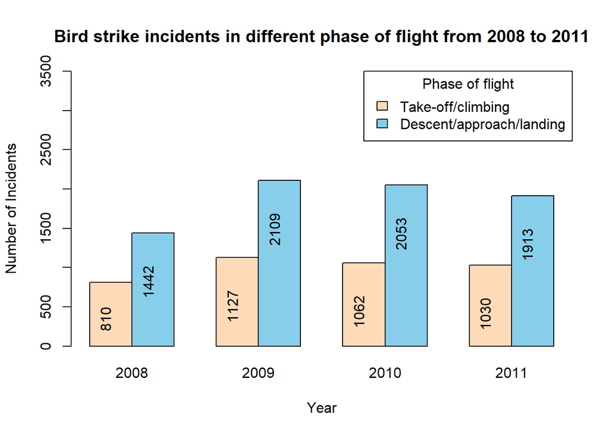

```r
# Graph Plot with year as X axis and number of incidents as Y

tempRs <- sqldf("select Year , al.'No of incidents' AS `I1`, ap.'No of incidents' AS `I2` from tempQ7Data1 al
                LEFT JOIN tempQ7Data2 ap USING (Year)")




#Taking the Dataset mentioned in the question
df = data.frame(Block = tempRs$Year, RTreg = tempRs$I1, RTrnd = tempRs$I2)

#Create a Matrix which will help in creating the plot
value_matrix = matrix( nrow = 2, ncol = 4)
value_matrix[1,] = df$RTreg
value_matrix[2,] = df$RTrnd

#Note that the "beside" argument has to be kept "TRUE" in order to place the bars side by side
yearBar <- barplot(value_matrix, names.arg = df$Block, beside = TRUE, col = c("peachpuff", "skyblue"),
        main="Bird strike incidents in different phase of flight from 2008 to 2011",  ylab="Number of Incidents",
        xlab = "Year", ylim = c(0, 3500), args.legend = list(title = "Phase of flight", x = "topright"),
        legend.text = c("Take-off/climbing","Descent/approach/landing"))

text(yearBar, value_matrix , labels = value_matrix, xpd = T, srt=90,  adj = c(2,0))
```

### Graph Plot with phase of flight as X axis and number of incidents as Y

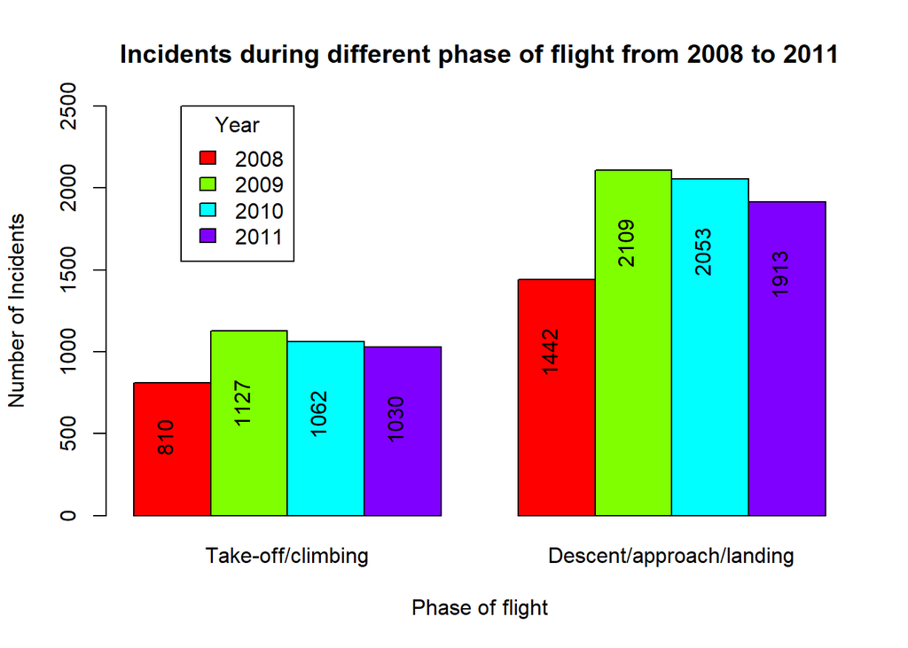

```r
## Graph Plot with phase of flight as X axis and number of incidents as Y

col1 <- tempQ7Data1$`No of incidents`
col2 <- tempQ7Data2$`No of incidents`

legendcol <- tempQ7Data2$Year


data <- data.frame(col1,col2)
names(data) <- c("Take-off/climbing","Descent/approach/landing")


bar <- barplot(height=as.matrix(data), main="Incidents during different phase of flight from 2008 to 2011",  ylab="Number of Incidents", xlab = "Phase of flight" ,legend.text = legendcol, beside=TRUE,col=rainbow(4), ylim = c(0, 2500),
        args.legend = list(title = "Year", x = "topleft", inset = c(0.10, 0)))


text(bar, as.matrix(data) , labels = as.matrix(data), xpd = T, srt=90,  adj = c(2,0))
```

## Question 7

### Initial check based on condition and getting count

```sql
SELECT COUNT(*)
    FROM Accidents
    WHERE airlineId = (
    SELECT airlineId
    FROM Airline WHERE airlineOperator = 'AIR CANADA'
    );
```

1 records

| COUNT(*) |
| --- |
| 95 |

### Drop procedure if exists

```sql
DROP PROCEDURE DeleteByAirlineName;
```

### Create the procedure with parameter passed into it

```sql
CREATE PROCEDURE DeleteByAirlineName(
    IN airLineName VARCHAR(255)
)
BEGIN
    DELETE
    FROM Accidents
    WHERE airlineId = (
    SELECT airlineId
    FROM Airline WHERE airlineOperator = airLineName
    );
end;
```

### Procedure call with parameter

```sql
CALL DeleteByAirlineName('AIR CANADA');
```

### Initial check based on condition and getting count as 0 after deleting

```sql
SELECT COUNT(*)
    FROM Accidents
    WHERE airlineId = (
    SELECT airlineId
    FROM Airline WHERE airlineOperator = 'AIR CANADA'
    );
```

1 records

| COUNT(*) |
| --- |
| 0 |

### Disconnectin the DB

```r
dbDisconnect(mydb)
```

```
## [1] TRUE
```